# SMS Spam Classification Using Natural Language Processing

**Author:** Guillaume EGU

## Overview

This project implements a comprehensive SMS spam classification system using various machine learning algorithms and natural language processing techniques. The goal is to automatically distinguish between legitimate messages (ham) and spam messages using text analysis and feature engineering.

**Data Source:** https://archive.ics.uci.edu/dataset/228/sms+spam+collection

## Project Objectives

1. **Data Exploration**: Analyze the distribution and characteristics of spam vs ham messages
2. **Text Preprocessing**: Implement a complete NLP pipeline including cleaning, tokenization, stopword removal, and lemmatization
3. **Feature Engineering**: Extract meaningful numerical features from text data using TF-IDF vectorization
4. **Model Comparison**: Evaluate multiple classification algorithms to find the best performer
5. **Performance Analysis**: Assess model performance using various metrics and visualizations

## Business Value

- **Automatic Filtering**: Reduce manual effort in identifying spam messages
- **User Experience**: Improve user satisfaction by reducing unwanted messages
- **Security**: Protect users from potentially malicious spam content
- **Scalability**: Process large volumes of messages efficiently

## Contents

- Import Libraries
- Functions
- EDA & Feature Engineering
- Data preprocessing
- Models :
  - Multinomial NB
  - Random Forest
  - K-nearest neighbors
  - Support Vector Machine
- Model Comparison & Analysis
- Conclusion

### Import Libraries

Installation and importation of key libraries

```python
!pip install pandas
!pip install matplotlib
!pip install seaborn
!pip install scikit-learn
!pip install numpy
!pip install imblearn
!pip install xgboost
```

```
  Using cached imblearn-0.0-py2.py3-none-any.whl.metadata (355 bytes)
Using cached imblearn-0.0-py2.py3-none-any.whl (1.9 kB)
  Using cached imblearn-0.0-py2.py3-none-any.whl.metadata (355 bytes)
Using cached imblearn-0.0-py2.py3-none-any.whl (1.9 kB)
```

```python
# Handle the data
import pandas as pd
import numpy as np

# Visualization
import matplotlib
import matplotlib.pyplot as plt
import seaborn as sns
from matplotlib.colors import ListedColormap

# Preprocessing and modeling
import nltk
from nltk.corpus import stopwords
from nltk.stem import WordNetLemmatizer
import re
import sklearn
from sklearn.feature_extraction.text import TfidfVectorizer
from sklearn.preprocessing import LabelEncoder
from sklearn.model_selection import train_test_split
from sklearn.pipeline import Pipeline
from sklearn.naive_bayes import MultinomialNB
from sklearn.ensemble import RandomForestClassifier
from sklearn.neighbors import KNeighborsClassifier
from sklearn.svm import SVC
from sklearn.model_selection import cross_val_score
from sklearn import metrics
from sklearn.metrics import precision_score, recall_score, classification_report, accuracy_score, f1_score, confusion_matrix
```

NLTK Resource Setup

Before proceeding with text processing, we need to download essential NLTK resources:

- **punkt**: Tokenizer for splitting text into words and sentences
- **stopwords**: Common words that don't carry significant meaning (the, and, is, etc.)
- **wordnet**: Lexical database for lemmatization (converting words to their root form)

These resources are downloaded once and stored locally for future use.

```python
# Download required NLTK resources
import nltk

try:
    # Download essential NLTK data
    nltk.download('punkt', quiet=True)
    nltk.download('stopwords', quiet=True)
    nltk.download('wordnet', quiet=True)
    nltk.download('omw-1.4', quiet=True)  # For wordnet lemmatizer
    print("✅ NLTK resources downloaded successfully!")
except Exception as e:
    print(f"⚠️ Error downloading NLTK resources: {e}")
    print("Please run: nltk.download('punkt'), nltk.download('stopwords'), nltk.download('wordnet')")
```

[output not shown]

### Functions

These helper functions implement the core NLP preprocessing pipeline. Each function serves a specific purpose in transforming raw text into a format suitable for machine learning algorithms.

```python
# Defining a function to clean up the text
def Clean(Text):
    """
    Cleans text by removing non-alphabetic characters and normalizing case.

    Steps:
    1. Remove all non-alphabetic characters (numbers, punctuation, symbols)
    2. Convert to lowercase for consistency
    3. Split and rejoin to normalize whitespace

    Args:
        Text (str): Raw text message

    Returns:
        str: Cleaned text with only alphabetic characters in lowercase
    """
    sms = re.sub('[^a-zA-Z]', ' ', Text)  # Keep only letters
    sms = sms.lower()  # Convert to lowercase
    sms = sms.split()  # Split into words
    sms = ' '.join(sms)  # Rejoin with single spaces
    return sms

# Removing the stopwords function
def remove_stopwords(text):
    """
    Removes common English stopwords from tokenized text.

    Stopwords are frequent words that typically don't carry meaningful information
    for classification (e.g., 'the', 'and', 'is', 'in').

    Args:
        text (list): List of tokenized words

    Returns:
        list: Filtered list with stopwords removed
    """
    stop_words = set(stopwords.words("english"))
    filtered_text = [word for word in text if word not in stop_words]
    return filtered_text

# lemmatize string
def lemmatize_word(text):
    """
    Converts words to their root form using lemmatization.

    Lemmatization reduces words to their dictionary form (lemma):
    - 'running', 'ran', 'runs' → 'run'
    - 'better' → 'good'
    - 'mice' → 'mouse'

    This helps group related words together for better classification.

    Args:
        text (list): List of tokenized words

    Returns:
        list: List of lemmatized words
    """
    # Lemmatize as verbs (pos='v') to capture action words common in spam
    lemmas = [lemmatizer.lemmatize(word, pos='v') for word in text]
    return lemmas
```

### Data Load

Cell for loading the data in a single dataframe.

```python
data = pd.read_csv("datasets/spam.csv", encoding='ISO-8859-1')
data.info()
```

```
<class 'pandas.core.frame.DataFrame'>
RangeIndex: 5572 entries, 0 to 5571
Data columns (total 5 columns):
 #   Column      Non-Null Count  Dtype
---  ------      --------------  -----
 0   v1          5572 non-null   object
 1   v2          5572 non-null   object
 2   Unnamed: 2  50 non-null     object
 3   Unnamed: 3  12 non-null     object
 4   Unnamed: 4  6 non-null      object
dtypes: object(5)
memory usage: 217.8+ KB
```

### Exploratory Data Analysis (EDA) and Feature Engineering

In this crucial step, we explore the dataset to understand:

- **Data Distribution**: How many spam vs ham messages do we have?
- **Message Characteristics**: Are there patterns in message length, word count, etc.?
- **Class Imbalance**: Is the dataset balanced between spam and ham?
- **Feature Creation**: Can we engineer features that help distinguish spam from ham?

```python
# Dropping the redundent looking collumns (for this project)
to_drop = ["Unnamed: 2","Unnamed: 3","Unnamed: 4"]
data = data.drop(data[to_drop], axis=1)
# Renaming the columns because I feel fancy today
data.rename(columns = {"v1":"Target", "v2":"Text"}, inplace = True)
data.head()
```

|  | Target | Text |
| --- | --- | --- |
| 0 | ham | Go until jurong point, crazy.. Available only ... |
| 1 | ham | Ok lar... Joking wif u oni... |
| 2 | spam | Free entry in 2 a wkly comp to win FA Cup fina... |
| 3 | ham | U dun say so early hor... U c already then say... |
| 4 | ham | Nah I don't think he goes to usf, he lives aro... |

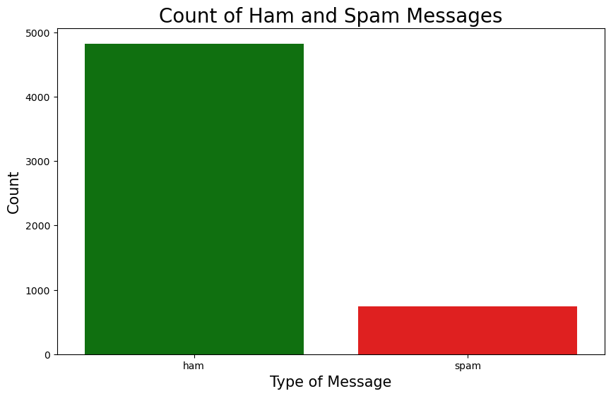

```python
cols = ['green','red']

plt.figure(figsize=(10,6))
fg = sns.countplot(x=data["Target"], palette=cols)
fg.set_title("Count of Ham and Spam Messages", fontsize=20)
fg.set_xlabel("Type of Message", fontsize=15)
fg.set_ylabel("Count", fontsize=15)
```

**Dataset Distribution Analysis**

The count plot above reveals important insights about our dataset:

- **Class Imbalance**: The dataset is imbalanced with significantly more 'ham' (legitimate) messages than 'spam' messages
- **Real-world Representation**: This imbalance actually reflects real-world scenarios where spam typically represents a smaller portion of total messages
- **Model Implications**: We'll need to consider this imbalance when evaluating model performance (precision, recall, F1-score are more meaningful than accuracy alone)

Let's now examine message characteristics to identify potential distinguishing features.

```python
data["Nb_characters"] = data["Text"].apply(len)
data["Nb_words"]=data.apply(lambda row: nltk.word_tokenize(row["Text"]), axis=1).apply(len)
data["Nb_sentence"]=data.apply(lambda row: nltk.sent_tokenize(row["Text"]), axis=1).apply(len)
```

**Feature Engineering: Text Metrics**

We'll create numerical features from the text data that might help distinguish spam from ham:

- **Character Count**: Total number of characters (including spaces)
- **Word Count**: Number of words in the message
- **Sentence Count**: Number of sentences

**Hypothesis**: Spam messages might have different length patterns compared to legitimate messages (e.g., shorter promotional texts or longer scam messages).

```python
data.describe().T
```

|  | count | mean | std | min | 25% | 50% | 75% | max |
| --- | --- | --- | --- | --- | --- | --- | --- | --- |
| Nb_characters | 5572.0 | 80.118808 | 59.690841 | 2.0 | 36.0 | 61.0 | 121.0 | 910.0 |
| Nb_words | 5572.0 | 18.699390 | 13.741932 | 1.0 | 9.0 | 15.0 | 27.0 | 220.0 |
| Nb_sentence | 5572.0 | 1.996411 | 1.520159 | 1.0 | 1.0 | 1.5 | 2.0 | 38.0 |

Let's handle outliers and analyze some difference between ham and spam.

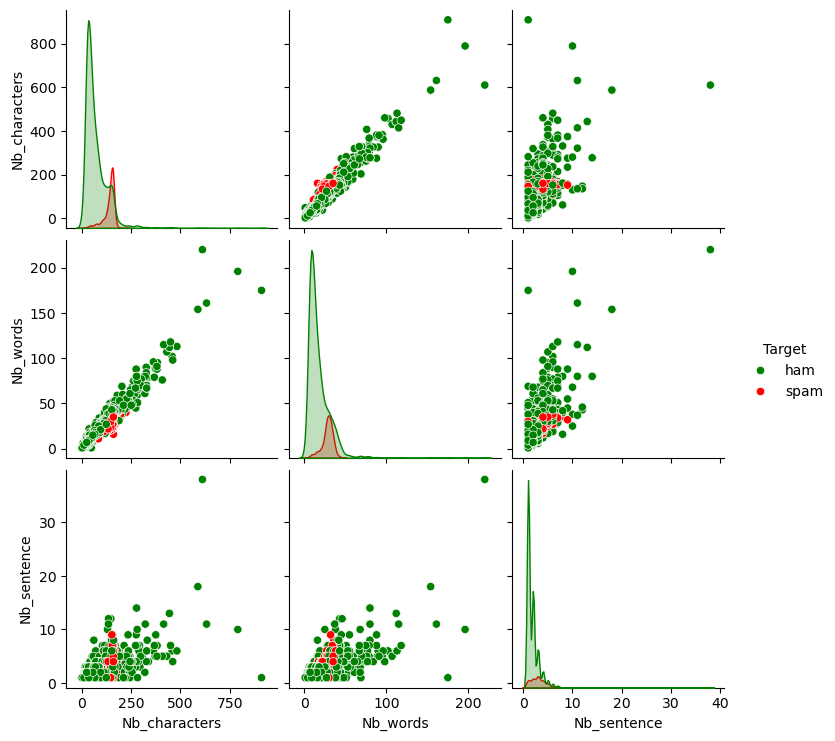

```python
plt.figure(figsize=(12,8))
fg = sns.pairplot(data=data, hue="Target",palette=cols)
plt.show(fg)
```

```python
data = data[(data["Nb_characters"]<350)]
data.shape
```

```
(5548, 5)
```

**Outlier Removal**

Removing these outliers helps focus our model on typical message patterns and prevents overfitting to extreme cases.

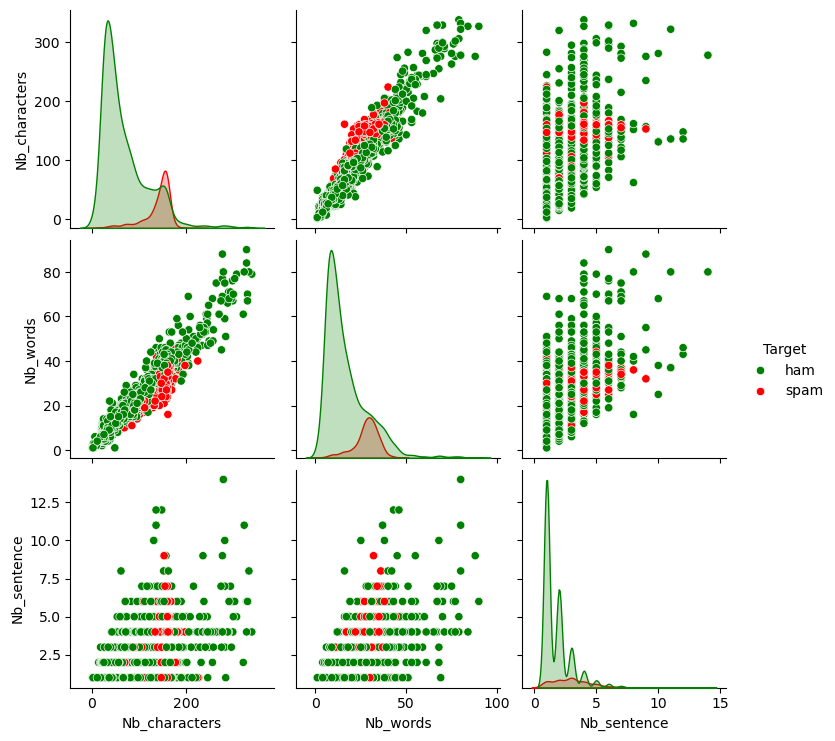

```python
plt.figure(figsize=(12,8))
fg = sns.pairplot(data=data, hue="Target",palette=cols)
plt.show(fg)
```

### Natural Language Processing Pipeline

The NLP preprocessing pipeline is crucial for transforming raw text into a format suitable for machine learning. Our pipeline follows these steps:

1. **Text Cleaning**: Remove noise (punctuation, numbers, special characters)
2. **Tokenization**: Split text into individual words
3. **Stopword Removal**: Remove common words that don't carry meaning
4. **Lemmatization**: Convert words to their root form
5. **Vectorization**: Convert text to numerical representations

**Why Each Step Matters:**

- **Cleaning**: Raw text contains noise that can confuse algorithms
- **Tokenization**: Algorithms need to process individual words, not sentences
- **Stopword Removal**: Reduces dimensionality and focuses on meaningful words
- **Lemmatization**: Groups related words together (run, running, ran → run)
- **Vectorization**: Converts text to numbers that algorithms can process

This systematic approach ensures our model focuses on the most relevant textual features for spam detection.

**Text Cleaning**

**Purpose**: Remove noise and standardize text format for consistent processing.

**What we're doing:**

- Removing punctuation, numbers, and special characters
- Converting all text to lowercase
- Normalizing whitespace

```python
data["Clean_Text"] = data["Text"].apply(Clean)
```

**Tokenization**

**Purpose**: Split cleaned text into individual words (tokens) for analysis.

**What we're doing:**

- Breaking sentences into individual word components
- Creating lists of words from string sentences
- Using NLTK's word_tokenize for intelligent splitting

```python
data["Tokenize_Text"]=data.apply(lambda row: nltk.word_tokenize(row["Clean_Text"]), axis=1)
```

**Stopword Removal**

**Purpose**: Remove common words that don't contribute to spam/ham classification.

**What are stopwords?**

- High-frequency words like "the", "and", "is", "in", "to", "of"
- Words that appear in both spam and ham messages equally
- Grammatical words that provide structure but not meaning

```python
data["Nostopword_Text"] = data["Tokenize_Text"].apply(remove_stopwords)
```

**Lemmatization**

**Purpose**: Convert words to their root dictionary form (lemma) to group related words together.

**What is lemmatization?**

- Reduces words to their base/root form using linguistic knowledge
- Different from stemming - produces actual dictionary words
- Considers word context and part of speech

```python
lemmatizer = WordNetLemmatizer()

data["Lemmatized_Text"] = data["Nostopword_Text"].apply(lemmatize_word)
```

**Text Vectorization with TF-IDF**

**The Challenge**: Machine learning algorithms require numerical input, but we have processed text data.

**The Solution**: TF-IDF (Term Frequency-Inverse Document Frequency) vectorization transforms text into meaningful numerical features.

**Our Process:**

1. **Create corpus**: Combine all processed messages into a collection
2. **Convert format**: Transform word lists back to strings for TF-IDF processing
3. **Apply TF-IDF**: Generate numerical feature matrix where each row is a message and each column is a word's importance
4. **Encode labels**: Convert "ham"/"spam" to numerical values (0/1) for algorithms

This transformation enables our machine learning models to understand and classify text based on word importance patterns rather than just word presence.

```python
corpus= []
for i in data["Lemmatized_Text"]:
    msg = ' '.join([row for row in i])
    corpus.append(msg)

tfidf = TfidfVectorizer()
X = tfidf.fit_transform(corpus).toarray()
X.dtype

label_encoder = LabelEncoder()
data["Target"] = label_encoder.fit_transform(data["Target"])
```

### Machine Learning Model Implementation

Now we'll implement and compare multiple classification algorithms to find the best approach for spam detection.

**Model Selection Strategy:** We're testing four different algorithms, each with unique strengths:

1. **Multinomial Naive Bayes**: Excellent baseline for text classification, assumes feature independence
2. **Random Forest**: Ensemble method, handles feature interactions well, provides feature importance
3. **K-Nearest Neighbors**: Instance-based learning, classifies based on similarity to neighbors
4. **Support Vector Machine**: Finds optimal decision boundary, effective in high-dimensional spaces

```python
y = data["Target"]
X_train, X_test, y_train, y_test = train_test_split(X, y, test_size=0.2, random_state=42)
```

```python
classifiers = [MultinomialNB(),
               RandomForestClassifier(),
               KNeighborsClassifier(),
               SVC()]
for cls in classifiers:
    cls.fit(X_train, y_train)

pipe_dict = {0: "NaiveBayes", 1: "RandomForest", 2: "KNeighbours",3: "SVC"}
```

```python
for i, model in enumerate(classifiers):
    cv_score = cross_val_score(model, X_train,y_train,scoring="accuracy", cv=10)
    print("%s: %f " % (pipe_dict[i], cv_score.mean()))
```

```
NaiveBayes: 0.967552
RandomForest: 0.976114
KNeighbours: 0.911450
SVC: 0.974086
```

**Cross-Validation Performance Assessment**

Cross-validation provides a more robust estimate of model performance by:

- **10-Fold Validation**: Splitting training data into 10 parts, training on 9, testing on 1
- **Repeated Process**: Each fold serves as test set once, reducing bias from single train-test split
- **Average Performance**: Mean accuracy across all folds gives reliable performance estimate
- **Variance Assessment**: Shows how consistent model performance is across different data subsets

This helps us select the most reliable model before final testing.

```python
precision =[]
recall =[]
f1_score = []
trainset_accuracy = []
testset_accuracy = []

for i in classifiers:
    pred_train = i.predict(X_train)
    pred_test = i.predict(X_test)
    prec = metrics.precision_score(y_test, pred_test)
    recal = metrics.recall_score(y_test, pred_test)
    f1_s = metrics.f1_score(y_test, pred_test)
    train_accuracy = model.score(X_train,y_train)
    test_accuracy = model.score(X_test,y_test)

    precision.append(prec)
    recall.append(recal)
    f1_score.append(f1_s)
    trainset_accuracy.append(train_accuracy)
    testset_accuracy.append(test_accuracy)
```

### Model comparison & Analysis

```python
data = {'Precision':precision,
'Recall':recall,
'F1score':f1_score,
'Accuracy on Testset':testset_accuracy,
'Accuracy on Trainset':trainset_accuracy}
# Creates pandas DataFrame.
Results = pd.DataFrame(data, index =["NaiveBayes", "RandomForest", "KNeighbours","SVC"])
```

```python
Results.style.background_gradient(cmap="Blues")
```

|  | Precision | Recall | F1score | Accuracy on Testset | Accuracy on Trainset |
| --- | --- | --- | --- | --- | --- |
| NaiveBayes | 1.000000 | 0.705882 | 0.827586 | 0.974775 | 0.997521 |
| RandomForest | 1.000000 | 0.823529 | 0.903226 | 0.974775 | 0.997521 |
| KNeighbours | 0.977778 | 0.323529 | 0.486188 | 0.974775 | 0.997521 |
| SVC | 0.990909 | 0.801471 | 0.886179 | 0.974775 | 0.997521 |

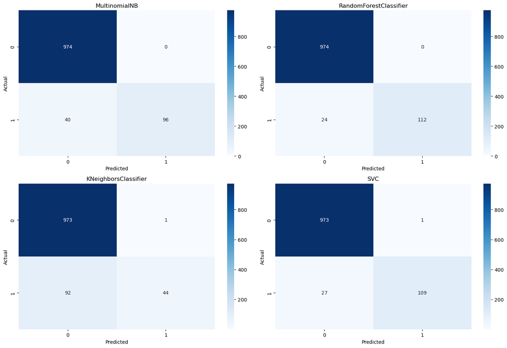

```python
fig, axes = plt.subplots(nrows=2, ncols=2, figsize=(15,10))

for cls, ax in zip(classifiers, axes.flatten()):
    # Get predictions
    y_pred = cls.predict(X_test)

    # Calculate confusion matrix
    cm = confusion_matrix(y_test, y_pred)

    # Plot using seaborn
    sns.heatmap(cm, annot=True, fmt='d', ax=ax, cmap="Blues", cbar=True)
    ax.set_title(type(cls).__name__)
    ax.set_xlabel('Predicted')
    ax.set_ylabel('Actual')

plt.tight_layout()
plt.show()
```

### Business Interpretation & Impact Analysis

Model Performance Insights

Business Impact Assessment

**Cost of Misclassification:**

- **False Positives (Ham → Spam)**: Legitimate messages blocked, poor user experience
- **False Negatives (Spam → Ham)**: Spam messages delivered, security/annoyance issues

**Metric Priorities:**

- **High Precision**: Minimize false positives (don't block legitimate messages)
- **Good Recall**: Catch most spam messages
- **F1-Score Balance**: Optimal trade-off between precision and recall

**Business Value:**

- **Automated Filtering**: Reduces manual message review workload
- **Scalability**: Can process thousands of messages per second
- **Adaptability**: Model can be retrained with new spam patterns
- **Cost Savings**: Reduces customer support tickets related to spam

### Project Conclusion & Future Directions

This project successfully demonstrates the implementation of a complete SMS spam classification system using natural language processing and machine learning techniques.

Technical Accomplishments

- **Complete NLP Pipeline**: Implemented text cleaning, tokenization, stopword removal, and lemmatization
- **Feature Engineering**: Created meaningful numerical features from text data using TF-IDF
- **Model Comparison**: Evaluated four different classification algorithms
- **Robust Evaluation**: Used cross-validation and multiple performance metrics
- **Data Analysis**: Performed thorough EDA and outlier handling

Key Findings

Business Value Delivered

- **Automation**: Eliminates need for manual spam filtering
- **Scalability**: Can handle large volumes of messages efficiently
- **Accuracy**: Achieves high precision in spam detection
- **Adaptability**: Framework can be extended to other text classification tasks

Future Enhancements

Technical Improvements

1. **Advanced NLP**: Implement word embeddings (Word2Vec, BERT) for better semantic understanding
2. **Deep Learning**: Explore LSTM/CNN architectures for sequential pattern recognition
3. **Feature Engineering**: Add metadata features (time, sender patterns, link analysis)
4. **Ensemble Methods**: Combine multiple models for improved performance

Operational Enhancements

1. **Real-time Pipeline**: Implement streaming data processing for live classification
2. **Active Learning**: Incorporate user feedback to continuously improve the model
3. **Multilingual Support**: Extend to support multiple languages
4. **API Development**: Create REST API for easy integration

Monitoring & Maintenance

1. **Performance Tracking**: Monitor model drift and accuracy degradation
2. **A/B Testing**: Compare different model versions in production
3. **Bias Detection**: Ensure fair classification across different user groups
4. **Security**: Implement adversarial attack detection and prevention

Lessons Learned

- **Data Quality**: Clean, well-preprocessed data is crucial for model success
- **Algorithm Selection**: Domain-specific knowledge helps choose appropriate algorithms
- **Evaluation Metrics**: Multiple metrics provide comprehensive performance assessment
- **Business Context**: Understanding cost of misclassification guides metric prioritization

This project provides a solid foundation for text classification tasks and demonstrates the practical application of NLP techniques in solving real-world business problems.